# Understanding the data

J. Ignacio Lucas Lledó

2025-07-24

# Mapping qualities

From a few samples.

```bash
RADBAM=../2024-10-04/BAM
REFBAM=../2023-05-18/BAM

if [ ! -d MQ ]; then mkdir MQ; fi
for pop in farionis pseudofarionis; do
   if [ ! -e MQ/$pop.sample.txt ]; then
      shuf ../2025-06-12/$pop.txt | head -n 5 > MQ/$pop.sample.txt
   fi
   if [ ! -e MQ/$pop.ref.mq.txt ]; then
      if [ ! -e MQ/$pop.ref.tmp ]; then
         for sample in $(cat MQ/$pop.sample.txt); do
            samtools view $REFBAM/$sample.bam | cut -f 5 >> MQ/$pop.ref.tmp
         done
      fi
      gawk '{F[$1]++}END{
         for (f in F) print f "\t" F[f]
      }' MQ/$pop.ref.tmp | sort -nk 1,1 > MQ/$pop.ref.mq.txt
   fi
   if [ ! -e MQ/$pop.rad.mq.txt ]; then
      if [ ! -e MQ/$pop.rad.tmp ]; then
         for sample in $(cat MQ/$pop.sample.txt); do
            samtools view $RADBAM/$sample.bam | cut -f 5 >> MQ/$pop.rad.tmp
         done
      fi
      gawk '{F[$1]++}END{
         for (f in F) print f "\t" F[f]
      }' MQ/$pop.rad.tmp | sort -nk 1,1 > MQ/$pop.rad.mq.txt
   fi
done
find MQ -name '*.tmp' -delete
```

The assembly is 206254914 nucleotides long, while the RAD loci add up to 40586257 nucleotides. The number of reads mapped to the assembly is 130043732, and those mapped to the RAD loci are twice as many: 262739636. But, reads mapped to RAD loci were not filtered by mapping quality: many have low mapping quality.

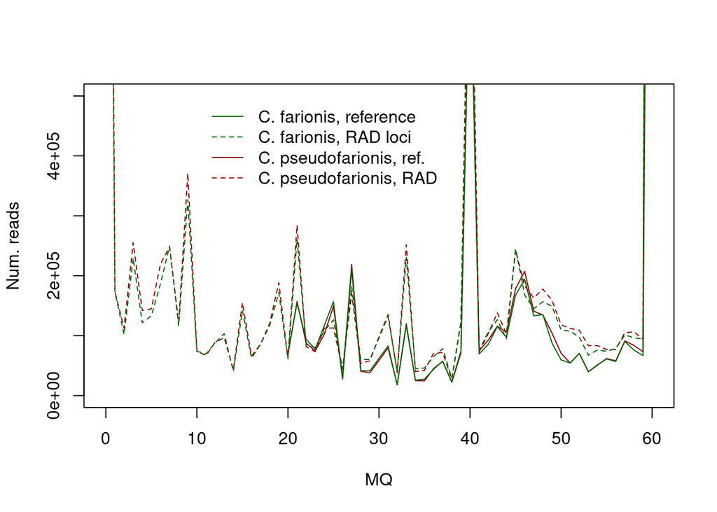

```r
library(ggplot2)
ref.pse <- read.table('MQ/pseudofarionis.ref.mq.txt',
                      col.names = c('MQ', 'freq'))
ref.pse$assembly <- 'ref'
ref.pse$pop      <- 'C. pseudofarionis'
ref.far <- read.table('MQ/farionis.ref.mq.txt',
                      col.names = c('MQ', 'freq'))
ref.far$assembly <- 'ref'
ref.far$pop      <- 'C. farionis'
rad.pse <- read.table('MQ/pseudofarionis.rad.mq.txt',
                      col.names = c('MQ', 'freq'))
rad.pse$assembly <- 'rad'
rad.pse$pop      <- 'C. pseudofarionis'
rad.far <- read.table('MQ/farionis.rad.mq.txt',
                      col.names = c('MQ', 'freq'))
rad.far$assembly <- 'rad'
rad.far$pop      <- 'C. farionis'
MQ <- rbind(ref.pse, ref.far, rad.pse, rad.far)
plot(c(0, 60), range(MQ$freq), type = 'n',
     xlab = 'MQ', ylab = 'Num. reads', ylim = c(0, 500000))
lines(ref.pse$MQ, ref.pse$freq, col = 'darkred', lty = 1)
lines(ref.far$MQ, ref.far$freq, col = 'darkgreen', lty = 1)
lines(rad.pse$MQ, rad.pse$freq, col = 'darkred', lty = 2)
lines(rad.far$MQ, rad.far$freq, col = 'darkgreen', lty = 2)
legend(10, 500000, c('C. farionis, reference',
                     'C. farionis, RAD loci',
                     'C. pseudofarionis, ref.',
                     'C. pseudofarionis, RAD'),
       lty = c(1, 2, 1, 2), bty = 'n',
       col = c('darkgreen', 'darkgreen', 'darkred', 'darkred'))
```

The number of reads mapped with high quality is still higher among mappings to the RAD loci than to the reference. Any threshold between 20 and 30 seems appropriate.

# Base quality distribution

From only a few samples, I explore the distribuion of base qualities among reads mapped with quality of at least 30.

```bash
RADBAM=../2024-10-04/BAM
REFBAM=../2023-05-18/BAM
if [ ! -d BQ ]; then mkdir BQ; fi
for pop in farionis pseudofarionis; do
   if [ ! -e BQ/$pop.sample.txt ]; then
      shuf ../2025-06-12/$pop.txt | head -n 5 > BQ/$pop.sample.txt
   fi
   if [ ! -e BQ/$pop.ref.bq.txt ]; then
      if [ ! -e BQ/$pop.ref.tmp.txt ]; then
         if [ ! -e BQ/$pop.ref.tmp.fq ]; then
            for sample in $(cat BQ/$pop.sample.txt); do
               samtools view -q 30 -u $REFBAM/$sample.bam | \
               samtools fastq >> BQ/$pop.ref.tmp.fq
            done
         fi
         vsearch --fastq_stats BQ/$pop.ref.tmp.fq \
                 --log BQ/$pop.ref.tmp.txt
      fi
      gawk 'BEGIN{
         ACTIVE = 0
      }(/^Q score distribution$/){
         ACTIVE = 1
         next
      }((ACTIVE == 1) && (/^[^-]/)){
         if (NF == 6) {
            print $0
         } else {
            ACTIVE = 0
         }
      }' BQ/$pop.ref.tmp.txt > BQ/$pop.ref.bq.txt
   fi
   if [ ! -e BQ/$pop.rad.bq.txt ]; then
      if [ ! -e BQ/$pop.rad.tmp.txt ]; then
         if [ ! -e BQ/$pop.rad.tmp.fq ]; then
            for sample in $(cat BQ/$pop.sample.txt); do
               samtools view -q 30 -u $RADBAM/$sample.bam | \
               samtools fastq >> BQ/$pop.rad.tmp.fq
            done
         fi
         vsearch --fastq_stats BQ/$pop.rad.tmp.fq \
                 --log BQ/$pop.rad.tmp.txt
      fi
      gawk 'BEGIN{
         ACTIVE = 0
      }(/^Q score distribution$/){
         ACTIVE = 1
         next
      }((ACTIVE == 1) && (/^[^-]/)){
         if (NF == 6) {
            print $0
         } else {
            ACTIVE = 0
         }
      }' BQ/$pop.rad.tmp.txt > BQ/$pop.rad.bq.txt
   fi
done
find BQ -name '*.tmp.*' -delete
```

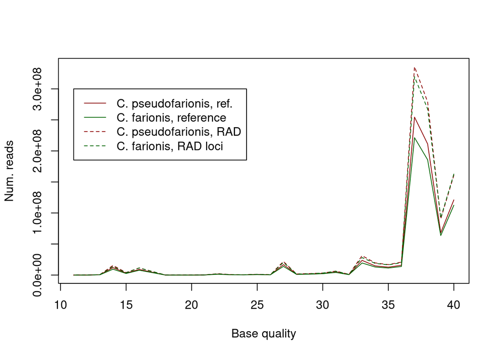

```r
ref.pse <- read.table('BQ/pseudofarionis.ref.bq.txt',
                      header = TRUE)
ref.far <- read.table('BQ/farionis.ref.bq.txt',
                      header = TRUE)
rad.pse <- read.table('BQ/pseudofarionis.rad.bq.txt',
                      header = TRUE)
rad.far <- read.table('BQ/farionis.rad.bq.txt',
                      header = TRUE)
plot(c(11, 40), c(0, max(c(ref.pse$N, ref.far$N, rad.pse$N, rad.far$N))),
     type = 'n', xlab = 'Base quality', ylab = 'Num. reads')
lines(ref.pse$Q, ref.pse$N, col = 'darkred', lty = 1)
lines(ref.far$Q, ref.far$N, col = 'darkgreen', lty = 1)
lines(rad.pse$Q, rad.pse$N, col = 'darkred', lty = 2)
lines(rad.far$Q, rad.far$N, col = 'darkgreen', lty = 2)
legend(11, 3.0e+08, c('C. pseudofarionis, ref.',
                      'C. farionis, reference',
                      'C. pseudofarionis, RAD',
                      'C. farionis, RAD loci'),
       lty = c(1, 1, 2, 2),
       col = c('darkred', 'darkgreen', 'darkred', 'darkgreen'))
```

A base quality threshold of 30 would be appropriate. Or even 35.

# Coverage

## Addequacy of thresholds

```bash
RADBAM=../2024-10-04/BAM
REFBAM=../2023-05-18/BAM
if [ ! -d COV ]; then mkdir COV; fi
for pop in farionis pseudofarionis; do
   if [ ! -e COV/$pop.ref.tmp ]; then
      ls -1 $REFBAM/*.bam | grep -F -f ../2025-06-12/$pop.txt | \
      xargs samtools depth -q 30 -Q 30 -o COV/$pop.ref.tmp
   fi
   if [ ! -e COV/$pop.rad.tmp ]; then
      ls -1 $RADBAM/*.bam | grep -F -f ../2025-06-12/$pop.txt | \
      xargs samtools depth -q 30 -Q 30 -o COV/$pop.rad.tmp
   fi
done
```

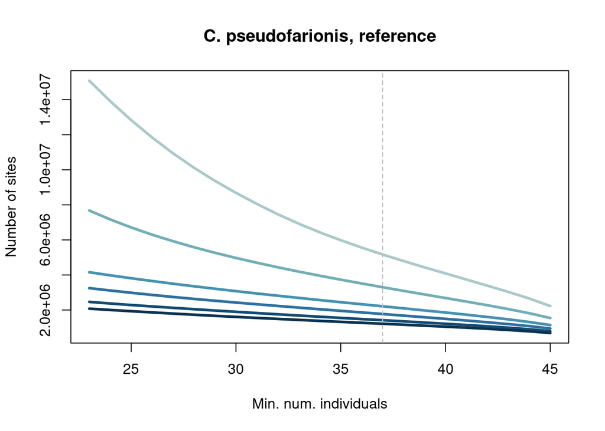

```r
library(MetBrewer)
library(ggplot2)
paleta <- met.brewer('Hokusai2', n=6)
minD <- 1:6

# C. pseudofarionis, reference
N <- length(scan('../2025-06-12/pseudofarionis.txt',
                 what = 'character', quiet = TRUE))
minN <- round(N / 2):(N - 1)
if (file.exists('COV/pseudofarionis.ref.txt')) {
   w <- read.table('COV/pseudofarionis.ref.txt')
} else {
   ref.pse <- read.table('COV/pseudofarionis.ref.tmp')
   ref.pse <- as.matrix(ref.pse[, -c(1,2)])
   w <- sapply(minD,
               function(x) {
                  sapply(minN,
                         function(y, i = x) {
                            sum(rowSums(ref.pse >= i) >= y)
                         })
               })
   colnames(w)  <- as.character(minD)
   row.names(w) <- as.character(minN)
   write.table(w, file = 'COV/pseudofarionis.ref.txt')
}

plot(range(minN), range(w), type = 'n',
     main = 'C. pseudofarionis, reference',
     xlab = 'Min. num. individuals', ylab = 'Number of sites')
for (i in 1:dim(w)[2]) {
   lines(minN, w[,i], col = paleta[i], lwd=3)
}
abline(v = round(4 * N / 5), lty = 2, col = 'gray')
```

Lines correspond to different thresholds of minimum coverage per individual, between 1 and 6.

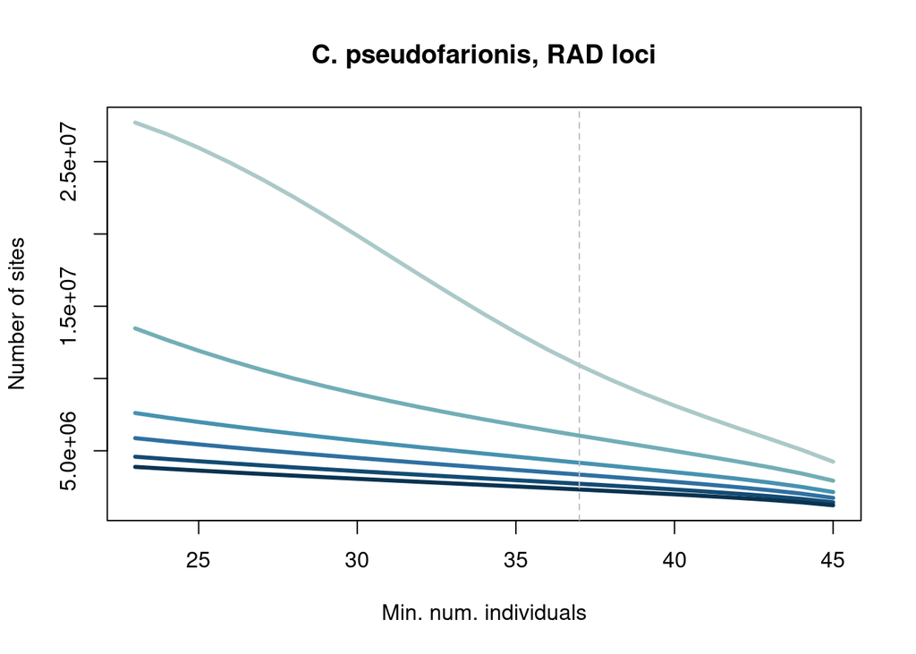

```r
# C. pseudofarionis, RAD loci
if (file.exists('COV/pseudofarionis.rad.txt')) {
   w <- read.table('COV/pseudofarionis.rad.txt')
} else {
   rad.pse <- read.table('COV/pseudofarionis.rad.tmp')
   rad.pse <- as.matrix(rad.pse[, -c(1,2)])
   w <- sapply(minD,
               function(x) {
                  sapply(minN,
                         function(y, i = x) {
                            sum(rowSums(rad.pse >= i) >= y)
                         })
               })
   colnames(w)  <- as.character(minD)
   row.names(w) <- as.character(minN)
   write.table(w, file = 'COV/pseudofarionis.rad.txt')
   # file.remove('COV/pseudofarionis.rad.tmp')
}

plot(range(minN), range(w), type = 'n',
     main = 'C. pseudofarionis, RAD loci',
     xlab = 'Min. num. individuals', ylab = 'Number of sites')
for (i in 1:dim(w)[2]) {
   lines(minN, w[,i], col = paleta[i], lwd=3)
}
abline(v = round(4 * N / 5), lty = 2, col = 'gray')
```

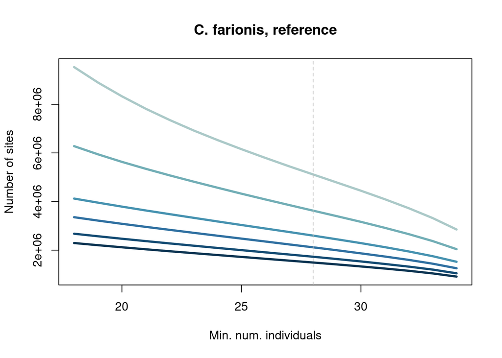

```r
# C. farionis, reference
N <- length(scan('../2025-06-12/farionis.txt',
                 what = 'character', quiet = TRUE))
minN <- round(N / 2):(N - 1)
if (file.exists('COV/farionis.ref.txt')) {
   w <- read.table('COV/farionis.ref.txt')
} else {
   ref.far <- read.table('COV/farionis.ref.tmp')
   ref.far <- as.matrix(ref.far[, -c(1,2)])
   w <- sapply(minD,
               function(x) {
                  sapply(minN,
                         function(y, i = x) {
                            sum(rowSums(ref.far >= i) >= y)
                         })
               })
   colnames(w)  <- as.character(minD)
   row.names(w) <- as.character(minN)
   write.table(w, file = 'COV/farionis.ref.txt')
   # file.remove('COV/farionis.ref.tmp')
}
plot(range(minN), range(w), type = 'n',
     main = 'C. farionis, reference',
     xlab = 'Min. num. individuals', ylab = 'Number of sites')
for (i in 1:dim(w)[2]) {
   lines(minN, w[,i], col = paleta[i], lwd=3)
}
abline(v = round(4 * N / 5), lty = 2, col = 'gray')
```

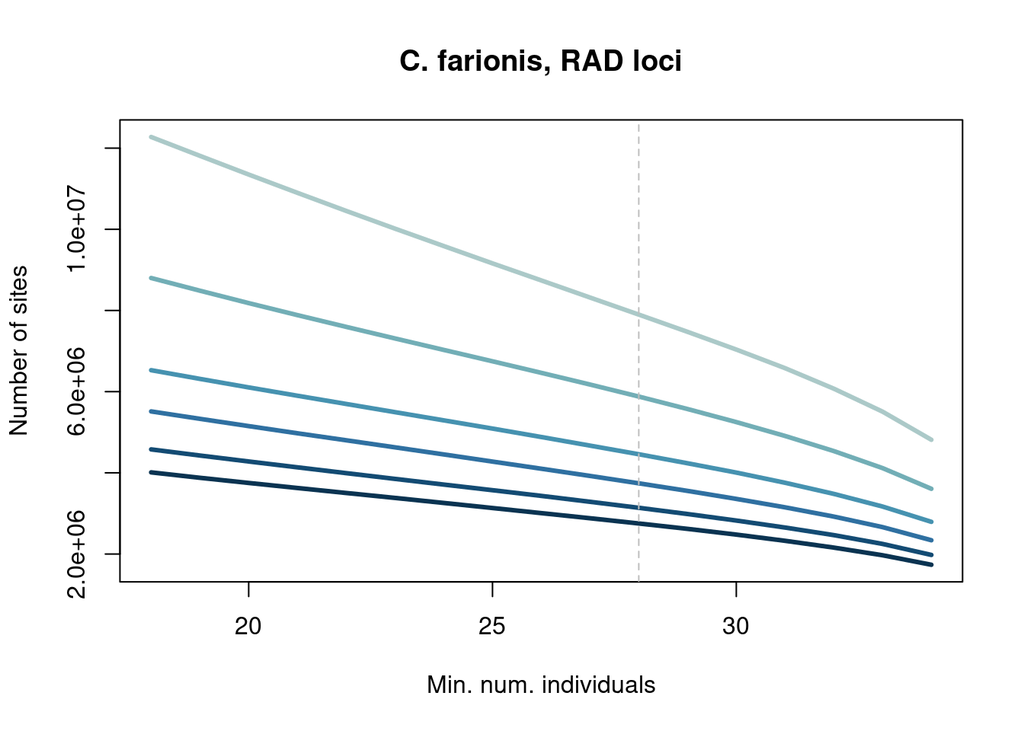

```r
# C. farionis, RAD loci
if (file.exists('COV/farionis.rad.txt')) {
   w <- read.table('COV/farionis.rad.txt')
} else {
   rad.far <- read.table('COV/farionis.rad.tmp')
   rad.far <- as.matrix(rad.far[, -c(1,2)])
   w <- sapply(minD,
               function(x) {
                  sapply(minN,
                         function(y, i = x) {
                            sum(rowSums(rad.far >= i) >= y)
                         })
               })
   colnames(w)  <- as.character(minD)
   row.names(w) <- as.character(minN)
   write.table(w, file = 'COV/farionis.rad.txt')
   # file.remove('COV/farionis.rad.tmp')
}
plot(range(minN), range(w), type = 'n',
     main = 'C. farionis, RAD loci',
     xlab = 'Min. num. individuals', ylab = 'Number of sites')
for (i in 1:dim(w)[2]) {
   lines(minN, w[,i], col = paleta[i], lwd=3)
}
abline(v = round(4 * N / 5), lty = 2, col = 'gray')
```

## Modeling

We have very large files with coverage per position per individual. Before erasing them, I should try to model coverage as a function of individual and contig. Coefficients of the model would then inform us what contigs have too much coverage, and maybe even what individuals have unexpected coverage levels for certain contigs. What kind of model should I use? Depth of coverage is count data, but usually with overdispersion with respect to a Poisson distribution. In our case, an excess of zeros is also expected. Thus, a **zero-inflated negative binomial** model should fit. However, values are heavily dependent among them, not independent. A **hidden Markov model** should be used to account for dependence. The package `depmixS4` could be used for that, either with a simple Poisson response model, or extending the response models to include the zero-inflated negative binomial. But that’s too much work, and too much computing time.

I envision three *states*: zero coverage, for not sequenced loci; low to moderate coverage on normal RAD loci; and very high coverage on collapsed repetitive genome regions. I’m afraid every sample needs to be modeled separately, instead of being a covariate in the response model. The contigs, which actually vary along the series of positions, could be used as covariates in the response model, but they would also influence the transition probabilities, which complicates the model.

The following is not run.

```r
suppressMessages(library(depmixS4))
suppressMessages(library(tidyr))
#ref.pse <- read.table('COV/pseudofarionis.ref.tmp',
ref.pse <- read.table('COV/z.pserefpart.tmp',
                      col.names = c('contig', 'pos',
                                    scan('../2025-06-12/pseudofarionis.txt',
                                         what = 'character', quiet = TRUE)))
ref.pse.l <- pivot_longer(
   ref.pse,
   cols = 3:ncol(ref.pse),
   names_to = 'sample',
   values_to = 'cov'
)

set.seed(1)
hmm <- depmix(response = S001Cma ~ 1,
              data = ref.pse,
              family = poisson(),
              nstates = 2,
              instart = c(0.99, 0.01),
              respstart = c(1, 100),
              trstart = c(0.95, 0.05,
                          0.05, 0.95))
```